# Karen’s Basket Inflation Index

2020-2025 grocery price inflation from a 394-product Wayback Machine basket

Grocery Pricing Project

April 29, 2026

# 1 Headline

This report computes an inflation index for “Karen’s basket” — 394 grocery products extracted from Wayback Machine snapshots of 15 chains, 2020-2025, restricted to non-sale prices. The basket is dominated by **Hannaford Supermarket & Pharmacy** (6,623 rows) and **Gordon Food Service** (6,560 rows), which together account for **88.6%** of all rows.

Headline (equal weights)

29.9%

cumulative 2020-2025 inflation

Bootstrap 95% CI

27.4% – 33.2%

5/95 percentiles, 500 resamples

BLS Food-at-Home (reference)

31.0%

BLS CPI-U FAH 2020-2025 (CUUR0000SAF11)

Robustness range (A-D)

29.2% — 33.9%

min – max across robustness scenarios

Weighting range (A-D)

29.9% — 38.0%

min – max across weighting schemes

Items in headline basket

338

(product, unit, qty) keys present in all 6 years

# 2 Basket overview

Raw input dataset

| metric | value |
| --- | --- |
| Rows | 14,873 |
| Distinct products | 394 |
| Distinct chains | 15 |
| Years covered | 2020 - 2025 |
| Categories | 10 |
| Wayback URLs | 3,289 |

Rows by chain (raw input)

| Chain | Rows | Share |
| --- | --- | --- |
| Hannaford Supermarket & Pharmacy | 6623 | 44.5% |
| Gordon Food Service Store Mp183 | 6560 | 44.1% |
| Trucchis Supermarket | 346 | 2.3% |
| Rouses Market | 299 | 2.0% |
| The Food Coop | 164 | 1.1% |
| French’s Meat Shoppe | 154 | 1.0% |
| Striplings General Store | 146 | 1.0% |
| W & L Kosher Meats | 144 | 1.0% |
| Abundance Food Co-op | 120 | 0.8% |
| Karns Quality Foods | 110 | 0.7% |
| Hays | 106 | 0.7% |
| Harter House | 33 | 0.2% |
| Old Creamery Co-op | 26 | 0.2% |
| Maxs Deli | 22 | 0.1% |
| Kenricks Meats and Catering | 20 | 0.1% |

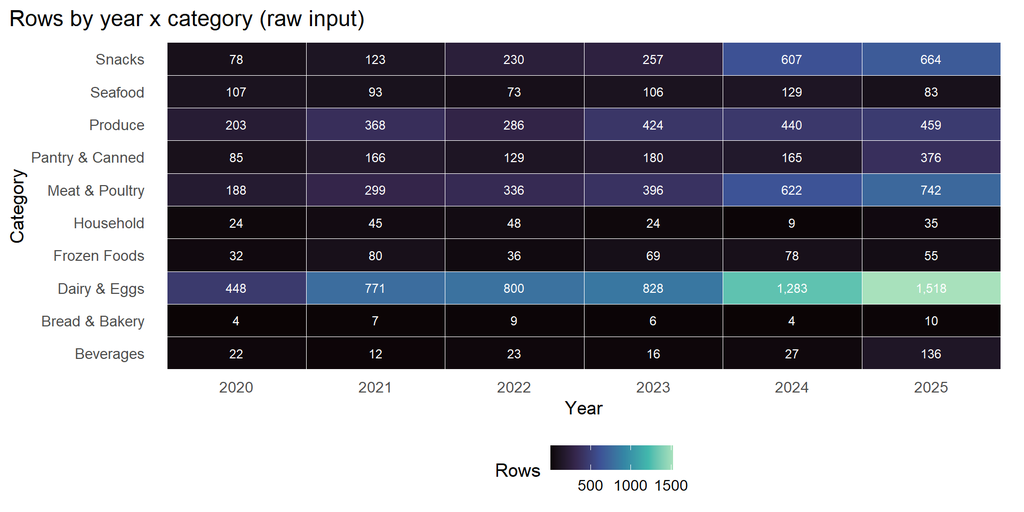

# 3 Data quality scan

A comprehensive scan identified the following issues. The cleaning pipeline below addresses each.

Data-quality scan results (issues found in raw input)

| Issue | Count | Action |
| --- | --- | --- |
| 1. Exact-row duplicates | 131 | Drop with distinct() |
| 2. Encoding-duplicated names (Macaroni & Cheese Entr??e variants) | 0 groups, 0 rows | Merge to canonical name (collapse non-ASCII to ?) |
| 3. Products with multiple unit labels (case/lb/bag mix) | 23 products | Treat (product, unit) as the indexing key |
| 4. Multi-distinct-price snapshots (package-size variants) | 1,878 groups, 4,360 rows | Use enrichment data (package_size_raw); else drop in robustness panel D |
| 5. Scraper-garbage product entries | 373 rows, 17 products | Drop products matching ’ USD’ / ‘Select Number of Trays’ / ‘Serves:’ |
| 6. Products with single 2020 observation | 130 (of 394) | Robustness panel B re-runs index requiring >=3 obs in 2020 |
| 7. Months covered per year (avg) | 12.0 | Aggregate price -> month -> year to neutralize timing imbalance |
| 8. Zero-variance products across 6 years (stale catalog?) | 8 products | Robustness panel C re-runs index excluding zero-variance products |
| 9. Rows missing unit field | 8,142 | Use enrichment data; otherwise treat as ‘no unit known’ |
| 10. Sale-flag = TRUE rows (input was filtered) | 0 | Confirms input filter held |

# 4 Cleaning pipeline

Cleaning pipeline

[output not shown]

Top single-observation outliers detected and removed (n=65 total)

| Item | Year | Outlier price | Item-year median (others) | Ratio |
| --- | --- | --- | --- | --- |
| Certified Angus Beef 80% Lean Ground Chuck \| unknown \| NA | 2025 | $248.00 | $2.48 | 100.0x |
| Hannaford Grade A Boneless Chicken Breast Family Pack \| unknown \| NA | 2024 | $125.00 | $2.49 | 50.2x |
| Salted Butter \| lb \| 1 | 2022 | $149.99 | $4.49 | 33.4x |
| Salted Butter \| lb \| 1 | 2025 | $129.99 | $3.99 | 32.6x |
| Salted Butter \| lb \| 1 | 2025 | $126.99 | $3.99 | 31.8x |
| Salted Butter \| lb \| 1 | 2025 | $125.99 | $3.99 | 31.6x |
| Salted Butter \| lb \| 1 | 2025 | $125.99 | $3.99 | 31.6x |
| Salted Butter \| lb \| 1 | 2025 | $125.99 | $3.99 | 31.6x |
| Salted Butter \| lb \| 1 | 2025 | $125.99 | $3.99 | 31.6x |
| Salted Butter \| lb \| 1 | 2025 | $124.99 | $3.99 | 31.3x |

The cleaned basket contains **338 items** across 12 chains, with **8,527 price observations**. The outlier-removal step caught 65 single-row anomalies — most often missing-decimal-point errors in the source HTML (e.g., one observation of “$248.00” for a beef product priced $2.48 in every other observation across 6 years).

# 5 Product-level price detail

Top 10 price increases 2020 -> 2025

| Product | Unit | 2020 ($) \|2025 ($) | Change |  |
| --- | --- | --- | --- | --- |
| Fresh Large Eggs | tray | 1.99 | 7.99 | 301.5% |
| Hannaford Medium Brown Eggs | ct | 0.13 | 0.49 | 270.4% |
| Hannaford Large White Eggs | ct | 0.10 | 0.33 | 235.3% |
| Hannaford Large Brown Eggs | ct | 0.14 | 0.42 | 196.4% |
| Hannaford Large Brown Eggs | ct | 0.14 | 0.42 | 195.3% |
| Hannaford Extra Large Brown Eggs | ct | 0.18 | 0.53 | 191.8% |
| Scrambled Eggs | unknown | 9.99 | 24.99 | 150.2% |
| Hannaford Large Brown Eggs | ct | 0.23 | 0.54 | 133.8% |
| Hannaford Jumbo Brown Eggs | ct | 0.25 | 0.55 | 120.4% |
| Heinz Simply Ketchup | oz | 0.10 | 0.22 | 117.9% |

Top 10 price decreases 2020 -> 2025

| Product | Unit | 2020 ($) \|2025 ($) | Change |  |
| --- | --- | --- | --- | --- |
| Nature’s Promise Chunk Light Tuna in Water | oz | 0.60 | 0.24 | -60.3% |
| Friendly’s Reese’s Peanut Butter Cup Sundae | oz | 0.50 | 0.28 | -43.7% |
| Hannaford 2% Reduced Fat Milk | unknown | 3.00 | 1.99 | -33.8% |
| Hannaford Yellow American Cheese | lb | 5.49 | 3.99 | -27.3% |
| Birds Eye Steamfresh Pasta & Broccoli with Cheese Sauce | oz | 0.37 | 0.28 | -25.2% |
| Hannaford 1% Low Fat Milk | unknown | 3.86 | 2.99 | -22.5% |
| StarKist Albacore White Tuna in Water | oz | 0.96 | 0.77 | -20.1% |
| Lettuce-boston/butter green/red organic | unknown | 3.01 | 2.42 | -19.6% |
| Hannaford White American Cheese | lb | 5.49 | 4.49 | -18.2% |
| Hannaford Grade A Chicken Leg Quarters | lb | 0.40 | 0.33 | -16.8% |

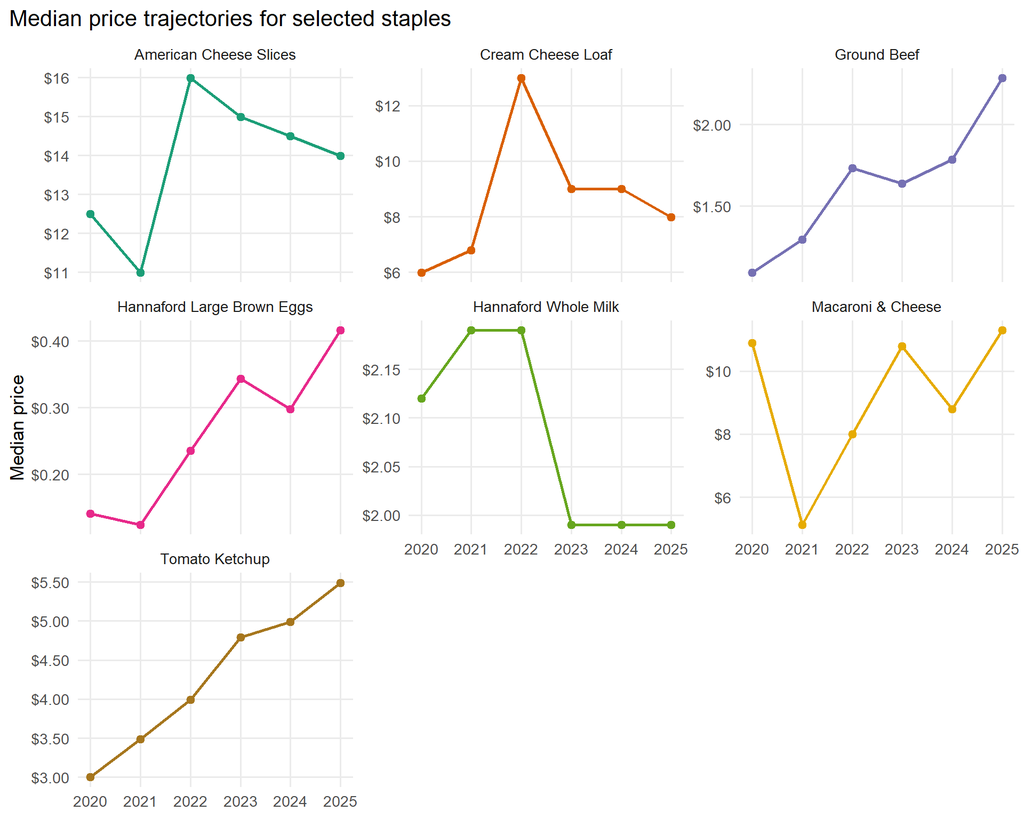

# 6 Index construction

We compute three classical price indices on the cleaned basket. Since our data has no quantities or expenditure shares, **fixed weights** are used (Paasche degenerates to Laspeyres under fixed weights; Fisher = sqrt(L * P) is reported as the standard summary).

**Within-year aggregation:** for each item we take the median price within each (year, month), then the mean across months — this neutralizes lumpy snapshot timing.

**Price relative:** $r_{i,t} = \tilde{p}_{i,t} / \tilde{p}_{i,2020}$

**Laspeyres index:** $L_t = \sum_i w_i^{2020} \cdot r_{i,t}$

**Paasche index:** $P_t = \sum_i w_i^{t} \cdot r_{i,t}$ — under fixed weights this equals Laspeyres.

**Fisher index:** $F_t = \sqrt{L_t \cdot P_t}$

The headline basket has **338 items** with valid 2020 anchor prices.

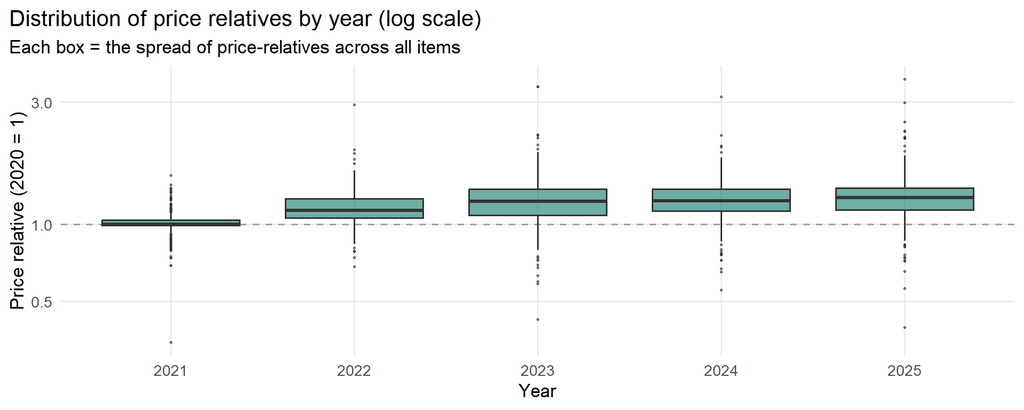

# 7 Headline index — equal product weights

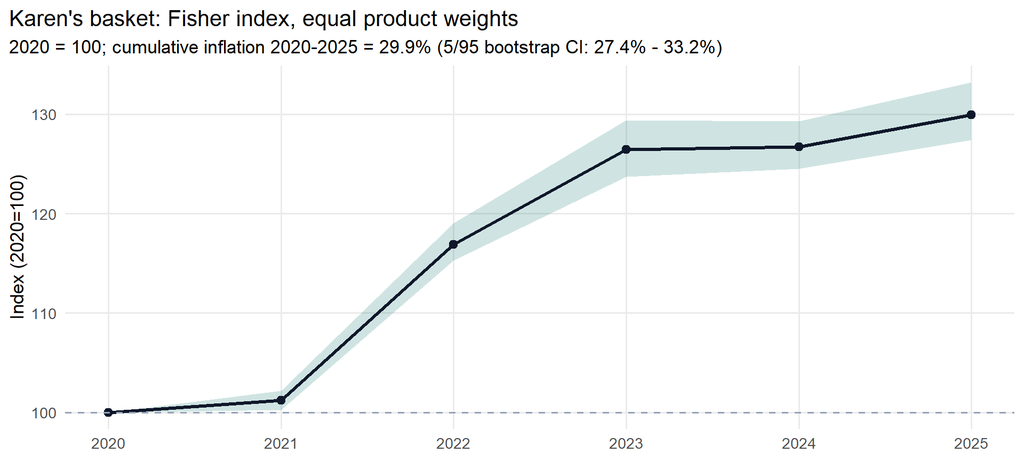

Headline index, equal product weights, with 500-resample bootstrap CIs

| Year | Fisher index | YoY change | Cumulative since 2020 | 5/95 bootstrap CI |
| --- | --- | --- | --- | --- |
| 2020 | 100.0 | - | 0.0% | 100.0 - 100.0 |
| 2021 | 101.2 | 1.2% | 1.2% | 100.3 - 102.2 |
| 2022 | 116.9 | 15.5% | 16.9% | 115.3 - 119.0 |
| 2023 | 126.4 | 8.2% | 26.4% | 123.7 - 129.4 |
| 2024 | 126.7 | 0.2% | 26.7% | 124.5 - 129.3 |
| 2025 | 129.9 | 2.5% | 29.9% | 127.4 - 133.2 |

## 7.1 Eggs decomposition

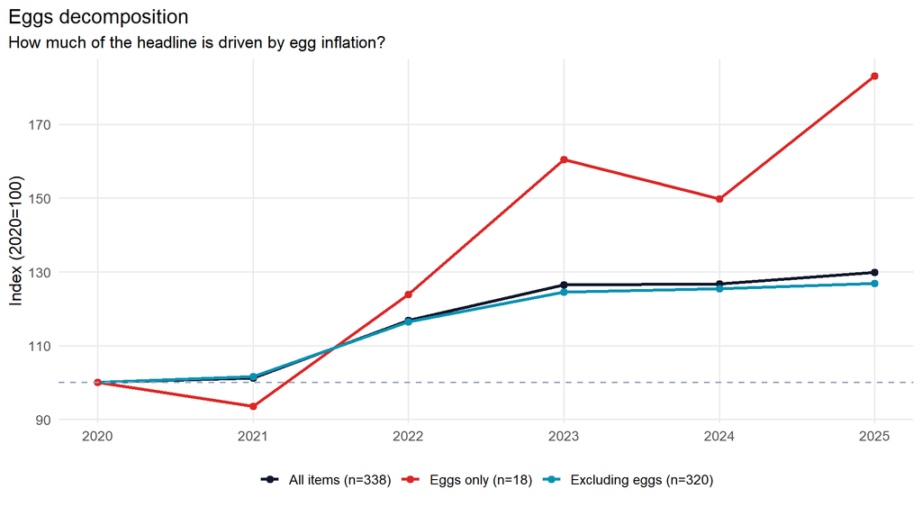

Headline with and without eggs

| Group | Fisher 2025 | Cumulative 2020-2025 |
| --- | --- | --- |
| All items (n=338) | 129.9 | 29.9% |
| Excluding eggs (n=320) | 126.9 | 26.9% |
| Eggs only (n=18) | 183.2 | 83.2% |

**Read:** eggs are 5.3% of the basket items but 83.2% inflated 2020-2025 (vs 26.9% for everything else). Removing eggs reduces the headline by **3.0pp** (29.9% -> 26.9%). Eggs are real inflation, not a basket-construction artifact, but their disproportionate price rise means a basket that’s heavy in eggs (relative to actual consumption) will overstate broad grocery inflation. NHANES weighting (Scheme C) is the most defensible mitigation since it down-weights any over-represented item to its consumption share.

# 8 Weighting sensitivity

We compare the headline (Scheme A: equal product weights) to three alternative weighting schemes:

- **A. Equal product weights** (headline): every item gets weight 1/N. No expenditure assumption.
- **B. Equal category weights**: each of the 10 grocery categories gets 1/10, distributed equally across the items within that category. Compromise that prevents heavily-stocked categories like Dairy & Eggs from dominating.
- **C. NHANES-informed**: category weights derived from NHANES `weighted_meals` shares mapped through `analysis/nhanes/category_group_lookup.csv` to our 10 categories. Most defensible expenditure proxy: it asks “what do American meals actually contain?” and lets that drive the weights. This is the scheme aligned with the project’s stated NHANES-informed weighting goal.
- **D. Observation-frequency**: each item is weighted by its share of *rows* in the cleaned basket ($w_i = n_i / \sum_j n_j$). This is **not** an expenditure share or a quantity share — it reflects how often the scraper happened to capture the item, which depends on Wayback snapshot density, page placement, and scraper retry behavior. It is included as a stress test: if it diverges sharply from the other schemes (as it does here, pushing the headline up), that signals the basket is dominated by a small number of heavily-scraped items whose price trajectory differs from the rest. It should not be read as a “true” expenditure-weighted index.

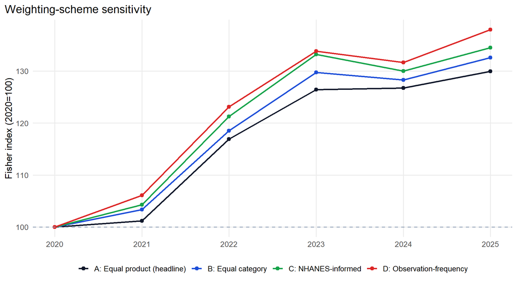

2020-2025 cumulative inflation by weighting scheme

| Scheme | Fisher 2025 | Cumulative inflation 2020-2025 |
| --- | --- | --- |
| A: Equal product (headline) | 129.9 | 29.9% |
| B: Equal category | 132.6 | 32.6% |
| C: NHANES-informed | 134.5 | 34.5% |
| D: Observation-frequency | 138.0 | 38.0% |

# 9 Robustness sensitivity

We re-run the headline index (equal product weights) under four robustness scenarios:

- **A. Cleaned baseline** (the headline)
- **B.** Restrict to items with >=3 observations in 2020 (mitigates thin base year)
- **C.** Drop items with zero price variance over 6 years (mitigates stale catalog)
- **D.** Drop items that ever had multi-distinct-price snapshots (more aggressive package-ambiguity defense than baseline)

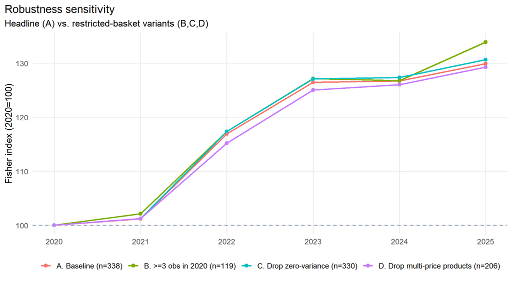

Robustness sensitivity: cumulative inflation 2020-2025

| Scenario | Fisher 2025 | Cumulative 2020-2025 |
| --- | --- | --- |
| A. Baseline (n=338) | 129.9 | 29.9% |
| B. >=3 obs in 2020 (n=119) | 133.9 | 33.9% |
| C. Drop zero-variance (n=330) | 130.6 | 30.6% |
| D. Drop multi-price products (n=206) | 129.2 | 29.2% |

**Honest answer:** across the four robustness scenarios, the cumulative 2020-2025 inflation lies in the range **29.2% to 33.9%**.

# 10 Chain-stratified index

The chain-stratified index is computed two ways: under **equal product weights** (Scheme A, the headline weighting) and under **NHANES-informed weights** (Scheme C, where each grocery category is weighted by NHANES national meal-frequency shares and that weight is distributed equally to items within the category). For each chain, the NHANES weights are renormalized within the chain so categories the chain doesn’t carry don’t drag the weight sum below 1.

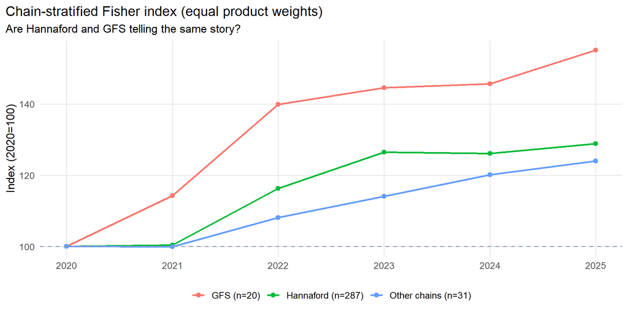

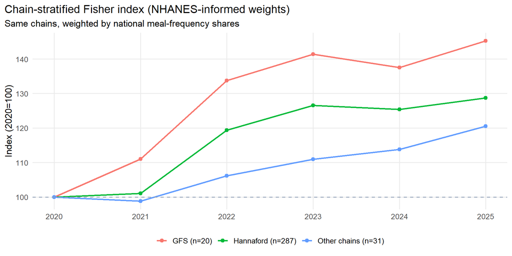

Cumulative inflation 2020 -> 2025, by chain and weighting scheme

| Chain | Items (n) | Equal weights (A) | NHANES (C) |
| --- | --- | --- | --- |
| Hannaford | 287 | 28.9% | 28.7% |
| GFS Mp183 | 20 | 55.1% | 45.2% |
| Other chains | 31 | 24.0% | 20.5% |
| Cross-chain range |  | 31.1 pp | 24.7 pp |

The cross-chain range tells you how much “chain choice” matters for inflation: a wider range means the chains diverge more on what their basket of items has done. Under NHANES weighting, that range typically shifts because chains with more items in NHANES-heavy categories (eggs, dairy, meat) get pulled toward the basket’s category-weighted average, while chains with idiosyncratic offerings (e.g., GFS’s wholesale-format catalog) move differently.

# 11 BLS Food-at-Home overlay

The Bureau of Labor Statistics publishes the Consumer Price Index for All Urban Consumers (CPI-U), Food at Home (series CUUR0000SAF11). Below we overlay our headline index against BLS annual averages for context.

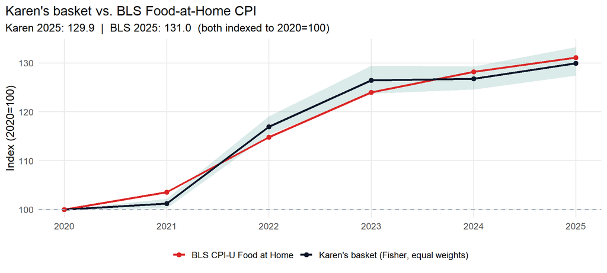

Karen’s basket vs. BLS Food-at-Home CPI, 2020 = 100

| Year | Karen’s basket | Karen’s CI | BLS Food-at-Home |
| --- | --- | --- | --- |
| 2020 | 100.0 | 100.0 - 100.0 | 100.0 |
| 2021 | 101.2 | 100.3 - 102.2 | 103.5 |
| 2022 | 116.9 | 115.3 - 119.0 | 114.8 |
| 2023 | 126.4 | 123.7 - 129.4 | 123.9 |
| 2024 | 126.7 | 124.5 - 129.3 | 128.1 |
| 2025 | 129.9 | 127.4 - 133.2 | 131.0 |

# 12 Validity caveats

Even after the cleaning pipeline, several limitations remain. The reader should treat the headline number as an order-of-magnitude estimate, not a precision instrument:

1. **Chain concentration.** 88.6% of rows come from two chains (Hannaford, GFS). This is much closer to a “Hannaford+GFS price story” than to “American grocery prices.”
2. **Geographic concentration.** Hannaford is a Northeast chain (NH/ME/VT/NY/MA); GFS Mp183 is a single-store identifier. The basket does not reflect Sunbelt or Pacific pricing.
3. **GFS retail vs. wholesale mixing.** GFS sells to both home and business customers; many products appear in both retail (per-lb) and wholesale (case) listings. Our case-vs-lb price-magnitude rule corrects the obvious cases but cannot detect every misattribution.
4. **Package size unknowns for non-Hannaford/GFS rows.** The re-scrape covered only Hannaford and GFS. Products from the other 13 chains keep their original (often missing) `unit` field.
5. **Sparse 2020 base.** Of 394 raw products, 130 had a single 2020 observation; the bootstrap CI quantifies but does not eliminate this noise.
6. **No quantities.** Without expenditure shares, all weighting schemes are heuristic. NHANES-informed weights are a defensible proxy but are based on national consumption averages, not basket purchase patterns.
7. **Wayback snapshot timing is irregular** within years. The month -> year aggregation reduces but does not eliminate timing artifacts.
8. **Sale-flag reliability** depends on each retailer’s labeling. The user’s filter (“non-sale”) survives only if retailers tagged sales correctly.
9. **Encoding-merged products** are now combined, but if a non-Hannaford retailer had different encoding artifacts we did not detect, those would still double-count.
10. **Index is fixed-weight throughout.** A true Paasche calculation requires period-specific quantities, which we lack; under fixed weights Paasche = Laspeyres and Fisher = sqrt(L*P) = L. We report the three to maintain the convention but note the equivalence.

# 13 Sources & reproducibility

The headline metric grid is at the top of this report. The numbers there are computed from the cleaned basket; the body sections above show the full derivation, sensitivity panels, and caveats.

*Inputs: `20260429_karens_basket_coverage.csv` (filtered non-sale subset of the project app, exported 2026-04-29). `analysis/karens_basket_enriched.csv` (Hannaford+GFS package-size enrichment via Wayback re-scrape, generated by `scripts/rescrape_basket_sizes.py`). NHANES weights via `analysis/nhanes/category_group_lookup.csv` and `analysis/nhanes/top_archetypes.csv`. BLS series CUUR0000SAF11.*

*Reproducibility: render with `./scripts/run-r.sh -e "rmarkdown::render('analysis/karens_basket_inflation.Rmd')"` from project root.*